# Tarea 5, equipo 7

N - N

2025-09-27

En una emocionante competencia de cubos Rubik, participantes de Chile, Argentina, Colombia, Uruguay, Perú y Ecuador demostraron su destreza en resolver tres tipos de cubos: 2x2x2, 3x3x3 y Megaminx.

Después del torneo, un grupo de investigadores de la Asociación Mundial del Cubo, interesado en los tiempos que hicieron las jugadoras y los jugadores en la competencia, decidieron estudiar si el país y el tipo de cubo usado en cada prueba tienen influencia en los segundos que se tardan en resolverlos. Para ello usaron una muestra aleatoria de los datos de la competencia, en la cual participaron más de 2.000 personas

¿Existen diferencias en el tiempo de resolución de cubos 2x2x2 entre participantes de Colombia, Chile y Uruguay?

Para resolver la pregunta de investigación planteada, en primer lugar se extraen los datos del dataset.

```r
datosCubos <- read.csv2("EP05 Datos.csv") %>% filter(tipo=="2x2x2", pais %in% c("Colombia", "Chile", "Uruguay"))
datosCubos$pais  <- factor(datosCubos$pais)
datosCubos$tiempo <- as.numeric(as.character(datosCubos$tiempo))
```

Con los datos extraídos, se procede a plantear las hipótesis. En este caso, debido a la naturaleza de la pregunta, la hipótesis planteada corresponde a una prueba ómnibus, la cual permite evaluar si existen diferencias globales entre un conjunto de grupos o condiciones, sin identificar específicamente entre cuáles de ellos se encuentran dichas diferencias.

Habiendo mencionado lo anterior, las hipótesis a contrastar son las siguientes:

$$H_0: \text{No existe diferencia en la
media de los tiempos de resolución de los cubos 2x2x2 entre
participantes de Colombia, Chile y Uruguay.}$$

$$H_a: \text{Al menos una de las medias
de los tiempos de resolución de los cubos 2x2x2 difiere entre los
participantes de Colombia, Chile y Uruguay.}$$

Tras haber definido las hipótesis y en vista de que hay al menos 3 muestras, todo parece apuntar a que hay que realizar una prueba de ANOVA para muestras independientes, sin embargo, antes de tomar esa decisión, es necesario verificar las condiciones para usar la prueba de ANOVA.

Las condiciones para el uso de la prueba son las siguientes:

1. La escala con que se mide la variable dependiente tiene las propiedades de una escala de intervalos iguales.

En vista de que la variable estudiada es el tiempo de resolución, el cual está medido en segundos por lo que se cumple la condición.

2. Las 3 muestras son obtenidas de manera aleatoria e independiente desde la(s) población(es) de origen.

De la misma forma que con la condición anterior, como cada participante es independiente de cada uno y participa solo una vez, las muestras son independientes y no hay dependencia entre grupos.

3. Se puede suponer razonablemente que la(s) población(es) de origen sigue(n) una distribución normal.

Para corroborar esto se realizan pruebas de normalidad.

```r
by(datosCubos$tiempo, datosCubos$pais, shapiro.test)
```

```
## datosCubos$pais: Chile
##
##  Shapiro-Wilk normality test
##
## data:  dd[x, ]
## W = 0.97831, p-value = 0.6119
##
## ------------------------------------------------------------
## datosCubos$pais: Colombia
##
##  Shapiro-Wilk normality test
##
## data:  dd[x, ]
## W = 0.97053, p-value = 0.374
##
## ------------------------------------------------------------
## datosCubos$pais: Uruguay
##
##  Shapiro-Wilk normality test
##
## data:  dd[x, ]
## W = 0.97483, p-value = 0.5539
```

Como se puede ver, los datos siguen una distribución normal, aunque para comprobarlo con más detalle se hacen gráficos QQ.

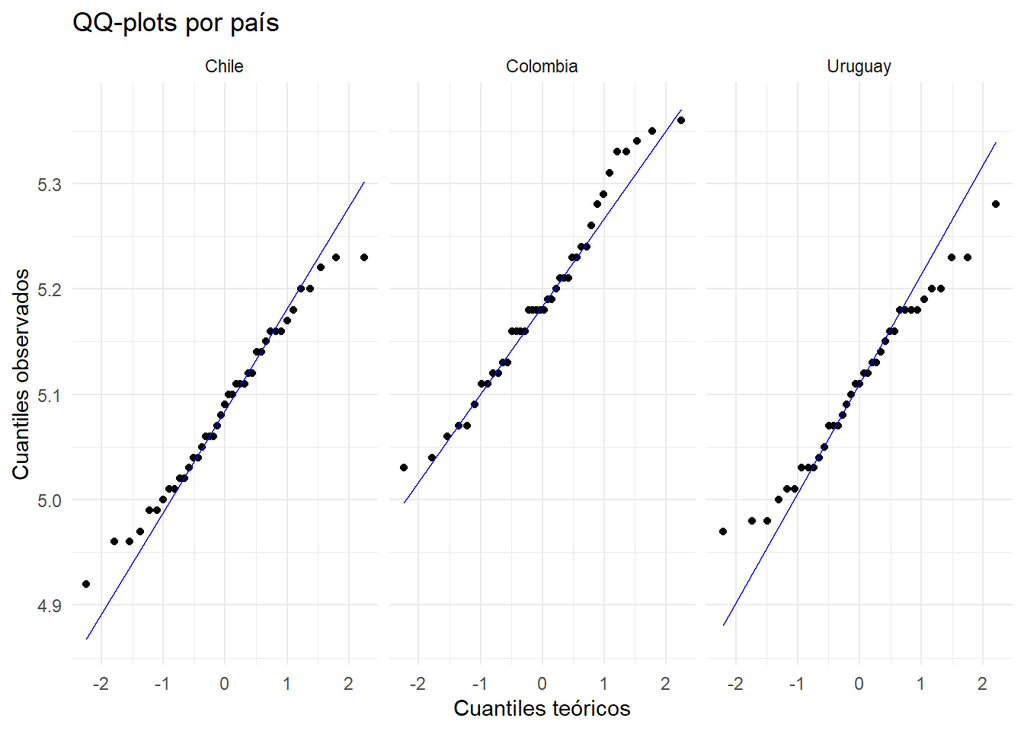

```r
g <- ggplot(datosCubos, aes(sample = tiempo)) +
      stat_qq() +
      stat_qq_line(color = "blue") +
      facet_wrap(~pais) +
      theme_minimal() +
      labs(title = "QQ-plots por país",
        x = "Cuantiles teóricos",
        y = "Cuantiles observados")
print(g)
```

Como se evidencia en los gráficos y en base a las pruebas de normalidad, se puede asumir que hay normalidad en los grupos estudiados.

4. Si las muestras provienen de más de una población, estas poblaciones tienen la misma varianza.

Para comprobar la homocedasticidad entre las muestras, se calcula la razón entre la máxima y la mínima varianza muestral de los grupos, que no sea superior a 1.5.

```r
datos_chile = datosCubos %>% filter(pais == "Chile")
datos_colombia = datosCubos %>% filter(pais == "Colombia")
datos_uruguay = datosCubos %>% filter(pais == "Uruguay")
varian_pais = c(var(datos_chile$tiempo),var(datos_colombia$tiempo),var(datos_uruguay$tiempo))
max(varian_pais) / min(varian_pais)
```

```
## [1] 1.219769
```

Dado que por criterio simple de razon, podemos considerar que la condicion de homocedasticidad se verifica al ser menor 1.5 la razon entre el maximo y minimo.

```r
test_anova = aov(tiempo ~ pais, data = datosCubos)
summary(test_anova)
```

```
##              Df Sum Sq Mean Sq F value   Pr(>F)
## pais          2 0.2424 0.12121   17.64 2.09e-07 ***
## Residuals   115 0.7904 0.00687
## ---
## Signif. codes:  0 '***' 0.001 '**' 0.01 '*' 0.05 '.' 0.1 ' ' 1
```

El valor p de la prueba ANOVA es 2.09e-07, esto indica que se rechaza la hipótesis nula y por ende, se prioriza la alternativa, es decir, al menos una de las medias de los tiempos de resolución de los cubos 2x2x2 difiere entre los participantes de Colombia, Chile y Uruguay.

En razón de esto es necesario realizar una prueba post-hoc para saber cuál grupo de los estudiados es el que difiere del resto de grupos en la muestra. La prueba post-hoc a utilizar, será HSD de Tukey-Kramer, siguiendo los siguientes supuestos garantizamos una mayor potencia estadística: supuestos de las condiciones de la prueba ANOVA y mismo número de observaciones por grupo. En este caso, se tiene una ligera diferencia entre grupos respecto a la cantidad de observaciones (Chile:41,Colombia:40 y Uruguay:37), para eso se encarga la adaptación de Tukey-Kramer.

```r
hsdKramer <- TukeyHSD(test_anova, "pais", ordered = TRUE, conf.level = 0.95)
hsdKramer$pais
```

```
##                        diff         lwr        upr        p adj
## Uruguay-Chile    0.02149637 -0.02313929 0.06613204 4.894290e-01
## Colombia-Chile   0.10415854  0.06041156 0.14790552 3.476084e-07
## Colombia-Uruguay 0.08266216  0.03776261 0.12756171 8.035856e-05
```

Analizando la prueba post-hoc se tiene que no hay una diferencia significativa entre las medias de tiempo de Uruguay y Chile. Los resultados dicen que la media de tiempos de Uruguay es 0.0215 mayor a la de Chile en un intervalo desde -0.0231 a 0.0661, que, al incluir el 0 no es una diferencia significativa y esto se confirma al ver el valor de p ajustado de 0.4894290, el cual es mayor a la significancia de 0.05.

En cuanto a Colombia, en base a los mismos análisis de antes se puede decir que es el grupo en que la media difiere del resto de valores, pues en ambos casos la diferencia entre las medias de tiempos de Colombia aumenta. Siendo que la media de tiempo de Colombia en comparación a Chile es 0.1042 mayor y en comparación a Uruguay es 0.0827 mayor. Además que el valor de p ajustado en ambas relaciones es menor a la significancia de 0.05. Esto indica que efectivamente la media que difiere del resto es la de Colombia.

En otras palabras, la media de los tiempos de resolución de cubos 2x2x2 de los participantes de Colombia es mayor a la media de los tiempos de resolución de cubos 2x2x2 de los participantes de Chile y Uruguay.